# STA 380 Homework 1: Barton, Jace

Jace Barton

August 5, 2015

To begin, I load the libraries I will need throughout my analysis.

```r
library(dplyr)
```

```r
library(mosaic)
library(ggplot2)
library(fImport)
library(foreach)
library(RCurl)
```

I will also be performing random draws. So the reader can reproduce my results, I will set the seed as value 722.

```r
set.seed(722)
```

Now, to the analysis!

# Exploratory Analysis

## County Voting in Georgia for 2000 Election

To begin, I will import the data set, then view a summary of the data.

```r
GeorgiaURLString = getURL("https://raw.githubusercontent.com/jacebarton/STA380/master/data/georgia2000.csv", ssl.verifypeer=0L, followlocation = 1L)
Georgia = read.csv(text=GeorgiaURLString)
summary(Georgia)
```

```
##       county       ballots           votes            equip
##  APPLING :  1   Min.   :   881   Min.   :   832   LEVER  :74
##  ATKINSON:  1   1st Qu.:  3694   1st Qu.:  3506   OPTICAL:66
##  BACON   :  1   Median :  6712   Median :  6299   PAPER  : 2
##  BAKER   :  1   Mean   : 16927   Mean   : 16331   PUNCH  :17
##  BALDWIN :  1   3rd Qu.: 12251   3rd Qu.: 11846
##  BANKS   :  1   Max.   :280975   Max.   :263211
##  (Other) :153
##       poor            urban           atlanta            perAA
##  Min.   :0.0000   Min.   :0.0000   Min.   :0.00000   Min.   :0.0000
##  1st Qu.:0.0000   1st Qu.:0.0000   1st Qu.:0.00000   1st Qu.:0.1115
##  Median :0.0000   Median :0.0000   Median :0.00000   Median :0.2330
##  Mean   :0.4528   Mean   :0.2642   Mean   :0.09434   Mean   :0.2430
##  3rd Qu.:1.0000   3rd Qu.:1.0000   3rd Qu.:0.00000   3rd Qu.:0.3480
##  Max.   :1.0000   Max.   :1.0000   Max.   :1.00000   Max.   :0.7650
##
##       gore             bush
##  Min.   :   249   Min.   :   271
##  1st Qu.:  1386   1st Qu.:  1804
##  Median :  2326   Median :  3597
##  Mean   :  7020   Mean   :  8929
##  3rd Qu.:  4430   3rd Qu.:  7468
##  Max.   :154509   Max.   :140494
##
```

I now want to calculate the undercount for each county and append that to the dataframe. I then want to look at a pivot table of the undercount by machine type.

```r
Georgia$undercount = abs(Georgia$votes - Georgia$ballots)
UndercountByEquip = group_by(Georgia, equip)
UndercountByEquip = summarise(UndercountByEquip, AvgUndercount = mean(Georgia$undercount), SumBallots = sum(Georgia$ballots), SumVotes = sum(Georgia$votes), BallotConversionRate = sum(Georgia$votes)/sum(Georgia$ballots))
UndercountByEquip
```

```
## Source: local data frame [4 x 5]
##
##     equip AvgUndercount SumBallots SumVotes BallotConversionRate
## 1   LEVER      229.9459     427780   410764            0.9602225
## 2 OPTICAL      592.2727    1436159  1397069            0.9727816
## 3   PAPER       56.5000       3454     3341            0.9672843
## 4   PUNCH     2262.4706     823921   785459            0.9533183
```

It appears that the punch equipment type is vastly undercounting. It is the second most used equipment type, but has the lowest conversion rate of ballots to votes at 95%. I want to look at this information graphically though to confirm my suspicions.

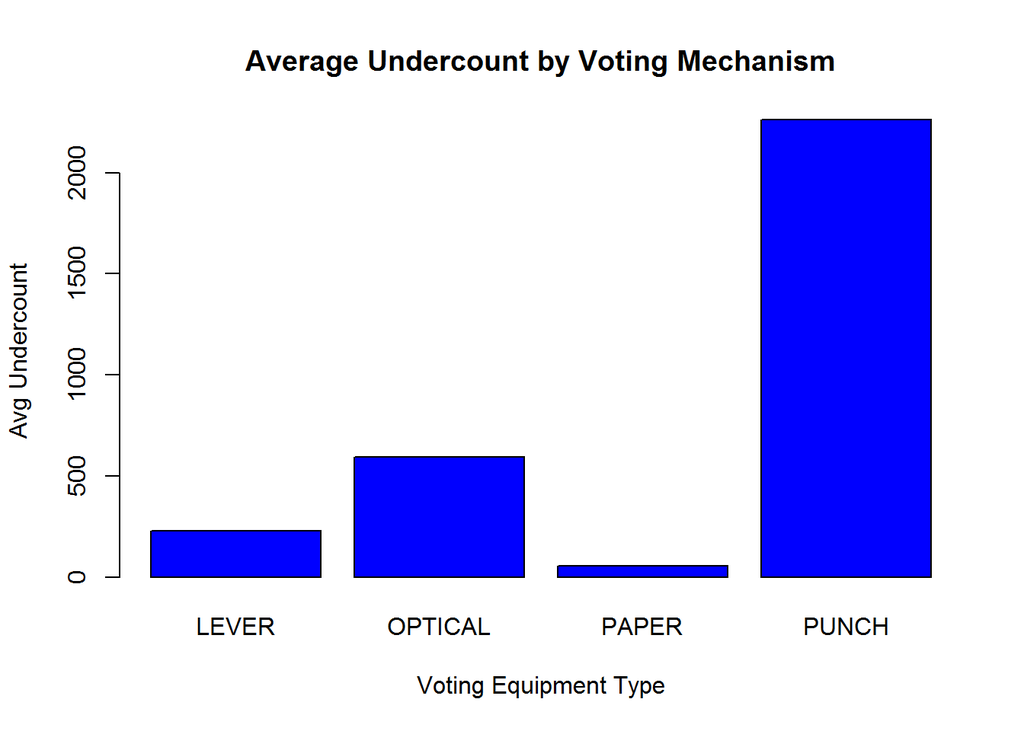

```r
barplot(UndercountByEquip$AvgUndercount, names = UndercountByEquip$equip, ylab="Avg Undercount", xlab="Voting Equipment Type", col=4, main="Average Undercount by Voting Mechanism")
```

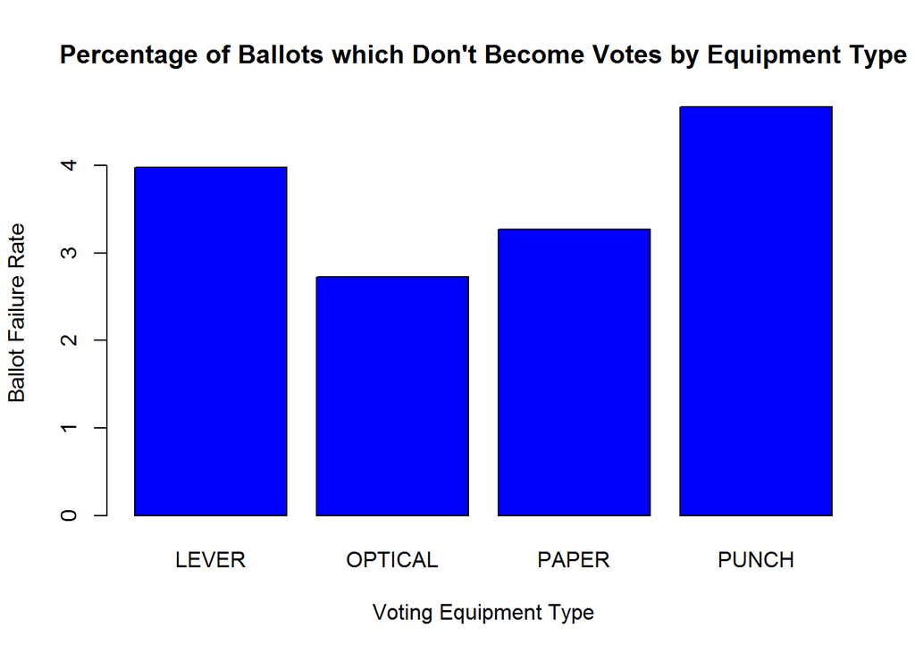

```r
barplot((1-UndercountByEquip$BallotConversionRate)*100, names = UndercountByEquip$equip, ylab="Ballot Failure Rate", xlab="Voting Equipment Type", col=4, main="Percentage of Ballots which Don't Become Votes by Equipment Type")
```

The punch equipment is the biggest offender. But where are the punch machines located? Are they equally spread across Georgia? Or are they located in areas which are poorer? Or have a higher percentage of minorities?

I begin by looking at a crosstab of county type (poor or rich) versus type of machine.

```r
PoorVsEquip = xtabs(~poor + equip, data=Georgia)
PoorVsEquip
```

```
##     equip
## poor LEVER OPTICAL PAPER PUNCH
##    0    29      48     0    10
##    1    45      18     2     7
```

```r
PoorVsEquipProp = prop.table(PoorVsEquip, margin=2)
PoorVsEquipProp
```

```
##     equip
## poor     LEVER   OPTICAL     PAPER     PUNCH
##    0 0.3918919 0.7272727 0.0000000 0.5882353
##    1 0.6081081 0.2727273 1.0000000 0.4117647
```

59% of punch machines were located in non-poor counties while 41% were located in poor counties. Thus, from this I can say non-poor counties were more likely to have their votes undercounted. But is that the full story?

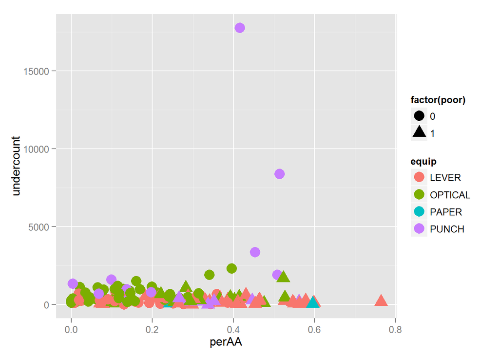

```r
ggplot(Georgia, aes(x=perAA, y=undercount, color = equip, shape = factor(poor))) + geom_point (size=5)
```

I immediately observe that the three counties with the most undercounted ballots were counties with a substantial African American population (greater than 40%). Those counties were also using punch cards. I also note that the right-most counties in the graph (the counties which are most substantially African-American in makeup) are poor.

In conclusion, punch machines see a higher rate of undercounting compared to other machine types. While the impact is spread between non-poor and poor counties about equally, minority counties are more likely to see substantial undercount than non-minority counties.

# Bootstrapping

## Stock market portfolios and levels of risk and return

The goal of this exercise is to see the levels of risk and return across varying compositions of different asset types. The asset types in question are domestic equities, Treasury bonds, corporate bonds, Emerging-market equities, and real estate. These five classes are represented in order by the following Exchange Traded Funds (ETFs). *SPY* TLT *LQD* EEM *VNQ

I first want to gather five years worth of returns on these five assets. This is accomplished below.

```r
MyExchangeTradedFunds = c("SPY", "TLT", "LQD", "EEM", "VNQ")
ETFPrices = yahooSeries(MyExchangeTradedFunds, from='2010-08-01', to='2015-07-31')

summary(ETFPrices)
```

```
##     SPY.Open        SPY.High        SPY.Low        SPY.Close
##  Min.   :104.9   Min.   :106.0   Min.   :104.3   Min.   :105.2
##  1st Qu.:131.7   1st Qu.:132.5   1st Qu.:131.0   1st Qu.:131.8
##  Median :149.9   Median :150.9   Median :149.5   Median :150.1
##  Mean   :158.5   Mean   :159.3   Mean   :157.7   Mean   :158.5
##  3rd Qu.:188.0   3rd Qu.:188.6   3rd Qu.:187.1   3rd Qu.:187.9
##  Max.   :213.2   Max.   :213.8   Max.   :212.9   Max.   :213.5
##    SPY.Volume        SPY.Adj.Close       TLT.Open         TLT.High
##  Min.   : 42963400   Min.   : 95.03   Min.   : 88.69   Min.   : 89.14
##  1st Qu.: 98758950   1st Qu.:121.34   1st Qu.:104.94   1st Qu.:105.54
##  Median :131278200   Median :142.94   Median :115.25   Median :115.75
##  Mean   :146760627   Mean   :151.67   Mean   :112.77   Mean   :113.33
##  3rd Qu.:173130100   3rd Qu.:183.42   3rd Qu.:120.80   3rd Qu.:121.39
##  Max.   :717828700   Max.   :212.62   Max.   :136.70   Max.   :138.50
##     TLT.Low         TLT.Close        TLT.Volume       TLT.Adj.Close
##  Min.   : 88.14   Min.   : 88.19   Min.   :  987200   Min.   : 77.11
##  1st Qu.:104.48   1st Qu.:105.11   1st Qu.: 5867950   1st Qu.: 98.49
##  Median :114.73   Median :115.29   Median : 7742500   Median :107.27
##  Mean   :112.24   Mean   :112.79   Mean   : 8644372   Mean   :105.25
##  3rd Qu.:120.29   3rd Qu.:120.84   3rd Qu.:10197050   3rd Qu.:114.67
##  Max.   :136.66   Max.   :138.28   Max.   :46221000   Max.   :136.27
##     LQD.Open        LQD.High        LQD.Low        LQD.Close
##  Min.   :106.7   Min.   :107.3   Min.   :106.3   Min.   :106.8
##  1st Qu.:112.7   1st Qu.:113.0   1st Qu.:112.4   1st Qu.:112.7
##  Median :116.1   Median :116.3   Median :115.9   Median :116.2
##  Mean   :115.9   Mean   :116.2   Mean   :115.7   Mean   :115.9
##  3rd Qu.:119.4   3rd Qu.:119.6   3rd Qu.:119.2   3rd Qu.:119.4
##  Max.   :123.5   Max.   :123.9   Max.   :123.4   Max.   :123.9
##    LQD.Volume       LQD.Adj.Close       EEM.Open        EEM.High
##  Min.   :  233400   Min.   : 89.53   Min.   :33.93   Min.   :34.94
##  1st Qu.: 1054650   1st Qu.: 98.21   1st Qu.:39.88   1st Qu.:40.18
##  Median : 1585400   Median :108.08   Median :41.79   Median :42.01
##  Mean   : 1809465   Mean   :106.13   Mean   :42.10   Mean   :42.33
##  3rd Qu.: 2241350   3rd Qu.:113.33   3rd Qu.:43.85   3rd Qu.:44.02
##  Max.   :10863900   Max.   :121.63   Max.   :50.27   Max.   :50.43
##     EEM.Low        EEM.Close       EEM.Volume        EEM.Adj.Close
##  Min.   :33.42   Min.   :34.36   Min.   : 18409100   Min.   :31.74
##  1st Qu.:39.62   1st Qu.:39.88   1st Qu.: 42995550   1st Qu.:38.24
##  Median :41.52   Median :41.79   Median : 53611300   Median :40.01
##  Mean   :41.83   Mean   :42.10   Mean   : 58088493   Mean   :39.94
##  3rd Qu.:43.66   3rd Qu.:43.86   3rd Qu.: 68977100   3rd Qu.:41.82
##  Max.   :49.94   Max.   :50.20   Max.   :191406700   Max.   :45.91
##     VNQ.Open        VNQ.High        VNQ.Low        VNQ.Close
##  Min.   :47.79   Min.   :49.34   Min.   :47.10   Min.   :48.47
##  1st Qu.:59.84   1st Qu.:60.26   1st Qu.:59.33   1st Qu.:59.97
##  Median :66.16   Median :66.51   Median :65.72   Median :66.20
##  Mean   :66.85   Mean   :67.27   Mean   :66.37   Mean   :66.84
##  3rd Qu.:73.85   3rd Qu.:74.30   3rd Qu.:73.50   3rd Qu.:73.88
##  Max.   :88.83   Max.   :89.27   Max.   :88.30   Max.   :88.65
##    VNQ.Volume       VNQ.Adj.Close
##  Min.   :  661100   Min.   :40.57
##  1st Qu.: 1839800   1st Qu.:51.33
##  Median : 2478900   Median :60.68
##  Mean   : 2849726   Mean   :61.20
##  3rd Qu.: 3410850   3rd Qu.:69.81
##  Max.   :11383300   Max.   :87.24
```

As seen, lots of information about the ETFs is returned by this data grab.However, for this theoretical exercise I am only interested in the returns of the assets. Below, I utilize a helper function presented in class by Dr. Scott to obtain the required returns.

```r
YahooPricesToReturns = function(series) {
  mycols = grep('Adj.Close', colnames(series))
  closingprice = series[,mycols]
  N = nrow(closingprice)
  percentreturn = as.data.frame(closingprice[2:N,]) / as.data.frame(closingprice[1:(N-1),]) - 1
  mynames = strsplit(colnames(percentreturn), '.', fixed=TRUE)
  mynames = lapply(mynames, function(x) return(paste0(x[1], ".PctReturn")))
  colnames(percentreturn) = mynames
  as.matrix(na.omit(percentreturn))
}
```

I will now calculate the returns, look at the scatter plots of each return type against each other return type, and view summary statistics of the returns.

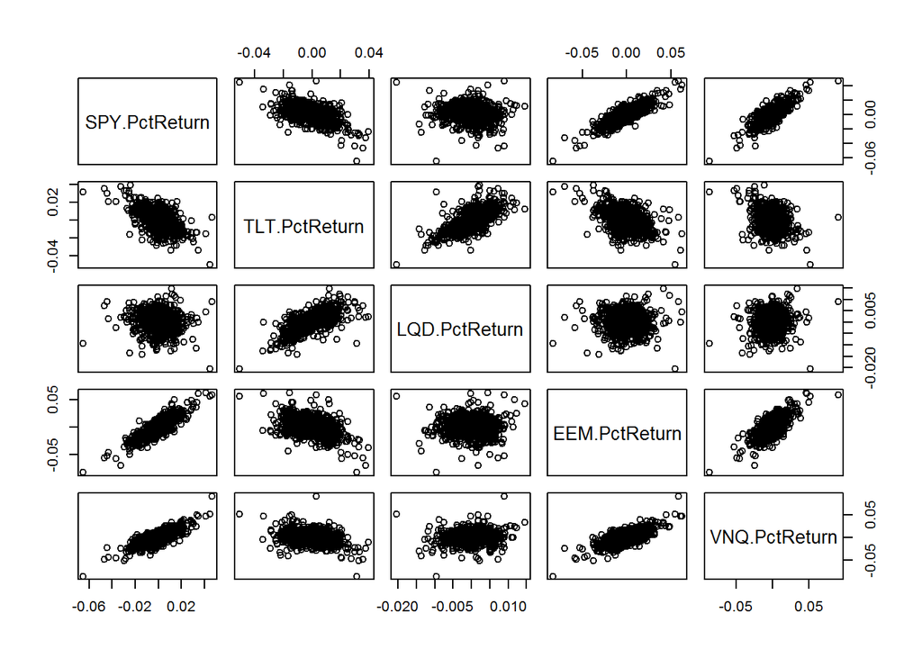

```r
ETFReturns = YahooPricesToReturns(ETFPrices)
pairs(ETFReturns)
```

```r
summary(ETFReturns)
```

```
##  SPY.PctReturn        TLT.PctReturn        LQD.PctReturn
##  Min.   :-0.0651232   Min.   :-0.0504495   Min.   :-0.0205232
##  1st Qu.:-0.0036944   1st Qu.:-0.0057510   1st Qu.:-0.0018105
##  Median : 0.0007426   Median : 0.0007862   Median : 0.0005005
##  Mean   : 0.0006210   Mean   : 0.0003404   Mean   : 0.0002036
##  3rd Qu.: 0.0053416   3rd Qu.: 0.0065291   3rd Qu.: 0.0022682
##  Max.   : 0.0464992   Max.   : 0.0396555   Max.   : 0.0146677
##  EEM.PctReturn        VNQ.PctReturn
##  Min.   :-8.337e-02   Min.   :-0.0868671
##  1st Qu.:-7.740e-03   1st Qu.:-0.0050551
##  Median : 4.649e-04   Median : 0.0009249
##  Mean   : 6.504e-05   Mean   : 0.0005391
##  3rd Qu.: 7.747e-03   3rd Qu.: 0.0066850
##  Max.   : 6.240e-02   Max.   : 0.0910393
```

What is the spread of these returns? I will look at the Standard Deviation (SD) and Interquartile Range (IQR) of each asset.

```r
ReturnSDs = rep(0,5)

for (i in 1:length(ReturnSDs)){
  ReturnSDs[i] = sd(ETFReturns[,i])
}

ReturnIQRs = rep(0,5)

for (i in 1:length(ReturnIQRs)){
  ReturnIQRs[i] = quantile(ETFReturns[,i], .75) - quantile(ETFReturns[,i], .25)
}

ReturnSDs
```

```
## [1] 0.009351005 0.009768007 0.003581299 0.013727342 0.011520712
```

```r
ReturnIQRs
```

```
## [1] 0.009035977 0.012280101 0.004078708 0.015486676 0.011740112
```

The results are similar. A standard deviation for each return type is about 1% (the exception being LQD) while the middle 50% of returns also varies by about 1%.

What do these returns look like as line graphs? As histograms?

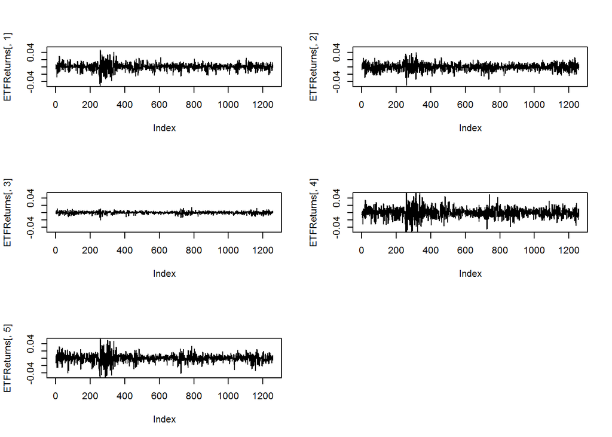

```r
par(mfrow=c(3,2))
plot(ETFReturns[,1], type='l', ylim=c(-.05, .05))
plot(ETFReturns[,2], type='l', ylim=c(-.05, .05))
plot(ETFReturns[,3], type='l', ylim=c(-.05, .05))
plot(ETFReturns[,4], type='l', ylim=c(-.05, .05))
plot(ETFReturns[,5], type='l', ylim=c(-.05, .05))

par(mfrow=c(3,2))
```

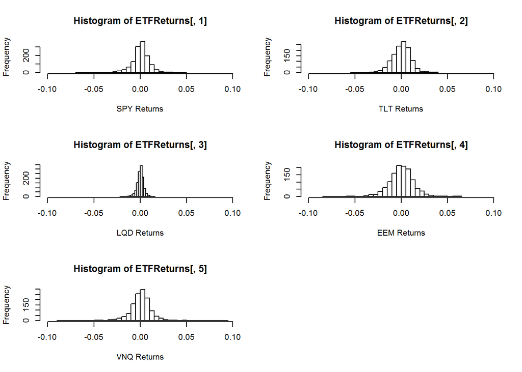

```r
hist(ETFReturns[,1], 25, xlim=c(-.10, .10), xlab="SPY Returns")
hist(ETFReturns[,2], 25, xlim=c(-.10, .10), xlab="TLT Returns")
hist(ETFReturns[,3], 25, xlim=c(-.10, .10), xlab="LQD Returns")
hist(ETFReturns[,4], 25, xlim=c(-.10, .10), xlab="EEM Returns")
hist(ETFReturns[,5], 50, xlim=c(-.10, .10), xlab="VNQ Returns")
```

While I will begin building my portfolios with an even split, eventually I will be interested in comprising risky and more reserved portfolios. Thus, looking at the volatility of each of the ETFs is informative. First off, I don’t observe any seasonality or obvious trends in any of the returns. I do notice that the LQD returns are by far the least volatile, followed by the ETF returns. The SPY returns are closer to the EEM Returns and the VNQ returns, but they do offer a middle ground. The main difference is the latter two ETFs have more instances of extreme returns than the SPY asset. I will keep all of this in mind for when I am choosing which assets to include in my risky and risk-averse portfolios.

But first, I begin by selecting a portfolio that is an even split of all five assets. I want to get a sense of how well this portfolio would perform in an average month (here defined as 20 trading days) of performance. To do this, I will randomly select 20 days of returns (with replacement) from the five years of return data. Rebalancing my money every day to maintain my desired 20-20-20-20-20 split, I will calculate how much money I possess at the end of the month. This will be one result. I will find 10,000 such results and average them together to get a sense of the true distribution of returns for this portfolio.

Below are the results for the Even Split Simulation.

```r
EvenSplitSimulation = foreach(i=1:10000, .combine='rbind') %do% {
  totalwealth = 100000
  weights = c(0.2, 0.2, 0.2, 0.2, 0.2)
  holdings = weights * totalwealth
  n_days = 20
  wealthtracker = rep(0, n_days) # Set up a placeholder to track total wealth
  for(today in 1:n_days) {
    return.today = resample(ETFReturns, 1, orig.ids=FALSE)
    holdings = holdings + holdings*return.today
    totalwealth = sum(holdings)
    wealthtracker[today] = totalwealth
    holdings = weights*totalwealth
  }
  totalwealth
}

summary(EvenSplitSimulation)
```

```
##        V1
##  Min.   : 88718
##  1st Qu.: 98945
##  Median :100718
##  Mean   :100712
##  3rd Qu.:102459
##  Max.   :111523
```

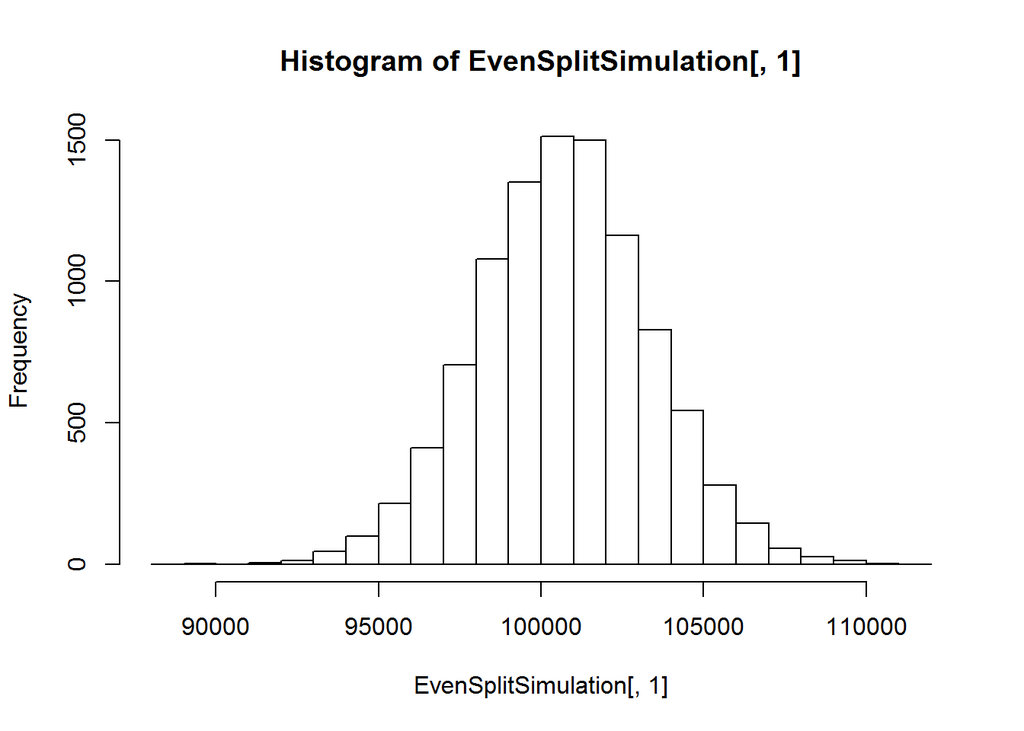

```r
par(mfrow=c(1,1))
hist(EvenSplitSimulation[,1], 25)
```

```r
sd(EvenSplitSimulation)
```

```
## [1] 2665.102
```

In terms of expected return, the center of the even split distribution is about $700. I can expect a standard deviation of about $2700.